# block ndvi

Lilac Hong

2026-04-28

## Methods

This residual analysis was adapted from Lambert et al. 2025.

### Baseline regressions (2010)

- Greenness linear model: NDVI_2010 = $\alpha$ + $\beta$ $\times$ log(HU_density_2010)

```
## TABLE 1: 2010 OLS Regression Coefficients (Greenness)
```

```
##   NDVI_2010 ~ log(HU_density_2010)
```

```
##          season buffer intercept      slope  slope_se    slope_p        R2
##  Dormant_Season   1000    0.4999  1.485e-03 4.173e-05 1.746e-275 1.504e-02
##  Growing_Season    500    0.5894  1.776e-03 4.594e-05  0.000e+00 1.773e-02
##  Growing_Season   1000    0.5905  9.857e-04 4.257e-05 3.328e-118 6.412e-03
##  Growing_Season   2000    0.5918 -9.433e-05 3.895e-05  1.544e-02 7.046e-05
##      n
##  82986
##  82783
##  83056
##  83253
```

### Residuals and pseudo-residuals

The 2010 residuals from each model served as a baseline “greenness:housing index” (GHI), analogous to the tree:housing index (THI) in Lambert et al. (2025):

- GHI_2010 = NDVI_2010 - $\hat{NDVI}_{2010}$ = NDVI_2010 - ($\hat{\alpha}_{2010}$ + $\hat{\beta}_{2010}$ $\times$ log(HU_density_2010))

Positive index values indicate a block that is greener than average for its housing density (**Bright**); negative values indicate the opposite (**Dim**). We then used the 2010 model coefficients with 2020 housing density data to generate expected 2020 values:

- $\hat{NDVI}_{2020}$ = $\hat{\alpha}_{2010}$ + $\hat{\beta}_{2010}$ $\times$ log(HU_density_2020)

The 2020 pseudo-residuals were computed as:

- GHI_2020 = NDVI_2020 - $\hat{NDVI}_{2020}$ = NDVI_2020 − ($\hat{\alpha}_{2010}$ + $\hat{\beta}_{2010}$ $\times$ log(HU_density_2020))

We classified each block’s state in each year as “Bright” (GHI $\geq$ 0) or “Dim” (GHI < 0) and tracked transitions between states (Bright → Bright, Bright → Dim, Dim → Bright, Dim → Dim).

### Change variables

We computed change in each index as:

- $\Delta$GHI = GHI_2020 − GHI_2010

Positive $\Delta$GHI values indicate “**brightening**”—a block became greener than expected relative to its housing density change, compared to the 2010 baseline. Negative values indicate “**dimming**.”

There are six possible cases in total:

| $GHI_{2010}$ | $GHI_{2020}$ | $\Delta$GHI | Interpretation |
| --- | --- | --- | --- |
| + (Bright) | + (Bright) | + (Brightened) | More bright |
| + (Bright) | + (Bright) | - (Dimmed) | Still bright but decrease |
| + (Bright) | - (Dim) | - (Dimmed) | The worst case |
| - (Dim) | + (Bright) | + (Brightened) | The best case |
| - (Dim) | - (Dim) | + (Brightened) | less dim |
| - (Dim) | - (Dim) | - (Dimmed) | more dim |

### Statistical comparisons across buffer and season

To assess whether the magnitude of brightening or dimming differed across buffer distances and seasons, we conducted:

1. Paired t-tests comparing dormant versus growing season change values within each buffer, pairing observations by census block (GEOID20).
2. One-way ANOVA (change ~ buffer) for greenness change variables, followed by a Tukey’s Honest Significant Difference (HSD) post-hoc tests for pairwise buffer comparisons within each season, and a cross-buffer correlation.

## Results

### Statistical comparisons across buffer and season

#### Paired t-tests: Season comparison within each buffer

The paired t-test is significant (p-value < 2.2e-16), indicating a meaningful difference between the dormant and growing seasons in greenness.

```
## PAIRED t-TEST: Dormant_Season_1000 vs Growing_Season_1000
```

```
##
##  Paired t-test
##
## data:  paired$Dormant_Season and paired$Growing_Season
## t = -237.24, df = 82979, p-value < 2.2e-16
## alternative hypothesis: true mean difference is not equal to 0
## 95 percent confidence interval:
##  -0.08941854 -0.08795316
## sample estimates:
## mean difference
##     -0.08868585
```

#### ANOVA (Tukey HSD) and correlation for buffer within each season

```
## ANOVA: change_green ~ buffer (Growing Season only)
```

```
##                 Df Sum Sq  Mean Sq F value Pr(>F)
## buffer_f         2   0.01 0.002907   3.057  0.047 *
## Residuals   249089 236.87 0.000951
## ---
## Signif. codes:  0 '***' 0.001 '**' 0.01 '*' 0.05 '.' 0.1 ' ' 1
```

```
##
## --- Tukey HSD pairwise buffer comparisons (Growing Season) ---
```

```
##   Tukey multiple comparisons of means
##     95% family-wise confidence level
##
## Fit: aov(formula = change_green ~ buffer_f, data = grow)
##
## $buffer_f
##                   diff           lwr          upr     p adj
## 1000-500  0.0001261784 -2.287743e-04 0.0004811311 0.6824060
## 2000-500  0.0003681134  1.337037e-05 0.0007228564 0.0398222
## 2000-1000 0.0002419350 -1.125155e-04 0.0005963856 0.2457275
```

```
## Cross-buffer ΔGHI correlation (Growing Season)
```

```
##         b500  b1000  b2000
## b500  1.0000 0.8144 0.5498
## b1000 0.8144 1.0000 0.7963
## b2000 0.5498 0.7963 1.0000
```

### Change variable summaries

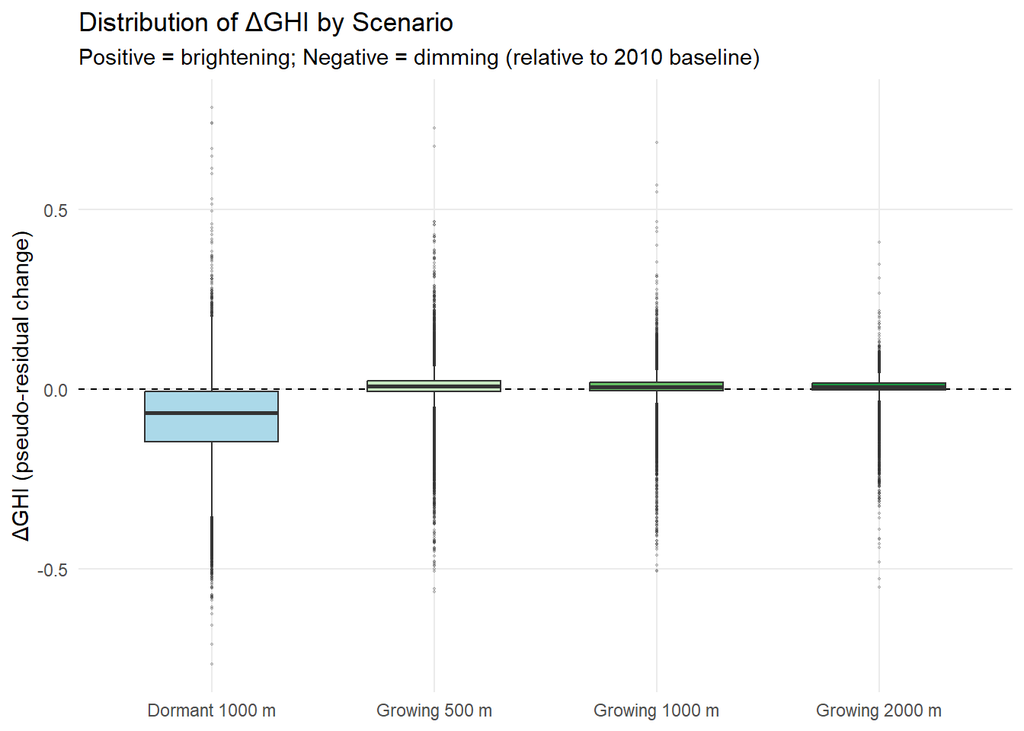

Table 2 reports the mean, standard deviation, and median of the greenness ($\Delta$GHI) for each season–buffer combination, along with the percentage of blocks that brightened or dimmed.

```
## TABLE 2: Greenness Change Summary by Scenario
```

```
##          season buffer     n mean_change_green sd_change_green
##  Dormant_Season   1000 82986         -0.083008         0.10496
##  Growing_Season    500 82783          0.005523         0.03750
##  Growing_Season   1000 83056          0.005649         0.03000
##  Growing_Season   2000 83253          0.005891         0.02344
##  median_change_green pct_brightened_green pct_dimmed_green
##            -0.065383                21.96            78.04
##             0.007667                64.62            35.38
##             0.007061                65.97            34.03
##             0.007099                68.47            31.53
```

### Bright/Dim transitions

Tables 3 reports the number of census blocks in each transition category (Bright → Bright, Bright → Dim, Dim → Bright, Dim → Dim) for greenness, stratified by season and buffer.

```
## TABLE 3: Greenness Bright/Dim Transitions (2010 -> 2020)
```

```
##          season buffer Bright -> Bright Bright -> Dim Dim -> Bright Dim -> Dim
##  Dormant_Season   1000            21417         20106          2674      38789
##  Growing_Season    500            40083          1893          3695      37112
##  Growing_Season   1000            40525          1385          2914      38232
##  Growing_Season   2000            41226          1306          2619      38102
```

### Visualization of ΔGHI

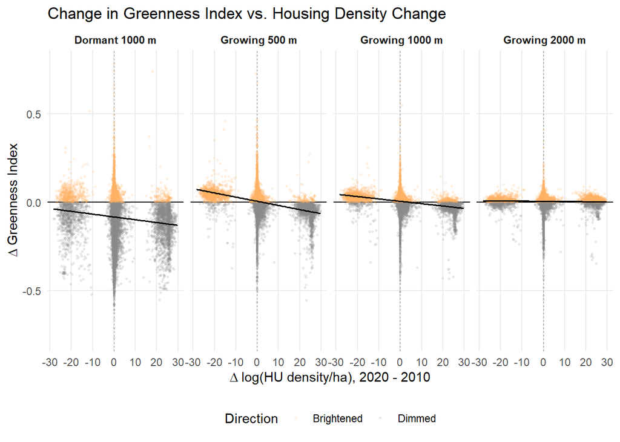

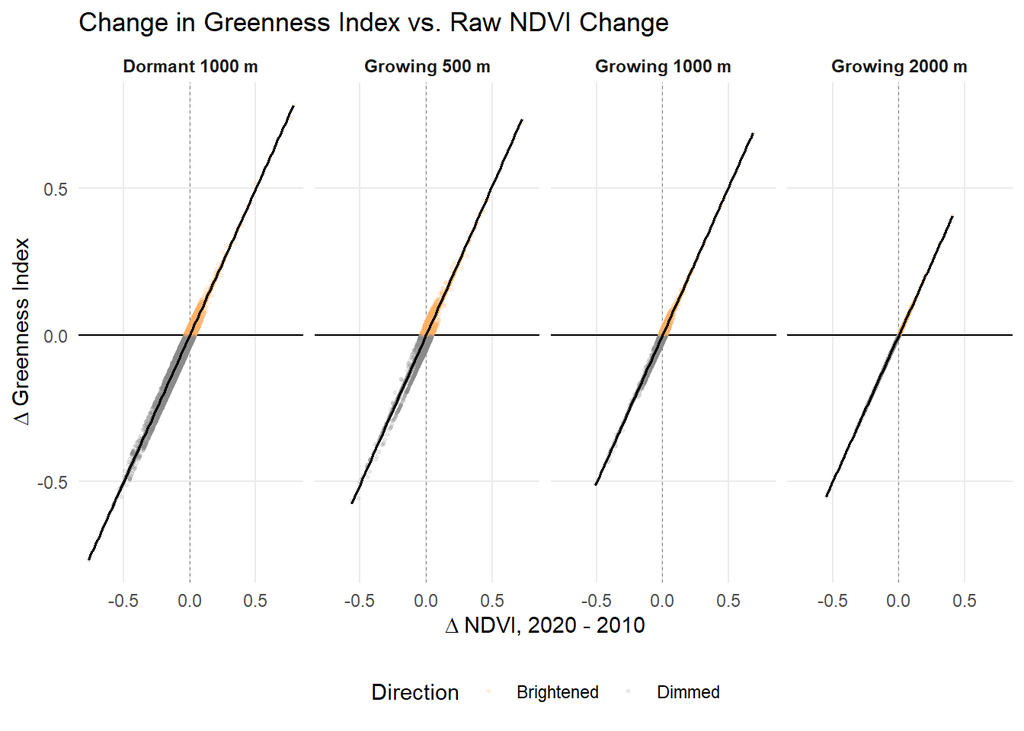